# Análise DuPont

Ross Cap 03

Marcelo S. Perlin

EA-UFRGS

21/08/2026

# Introdução à Análise DuPont

## Pergunta

Dados os vários índices financeiros da aula anterior, caso tivesses que escolher apenas um deles para tomar uma decisão sobre a compra das ações de uma empresa, qual escolheria?

1. Índice de liquidez geral
2. Índice de liquidez seca
3. Giro do ativo
4. ROA – Retorno sobre ativos
5. **ROE – Retorno sobre capital próprio**

**Resposta: e) ROE**

O **ROE (Return on Equity)** é a principal medida do retorno gerado para os acionistas. A **Análise DuPont** nos permite “desmontar” o ROE para entender *de onde* vem esse desempenho (lucratividade, eficiência ou alavancagem).

## A Identidade DuPont

> A análise DuPont é uma ferramenta essencial para decompor e analisar a rentabilidade de uma empresa.
- Criada em 1912 por **Donaldson Brown**, engenheiro elétrico na empresa DuPont.
- **Ideia básica**: Decompor o ROE em três pilares fundamentais:
  - **Margem Líquida** (Lucratividade)
  - **Giro dos Ativos** (Eficiência)
  - **Alavancagem Financeira** (Multiplicador do PL)

### Importância

- Permite entender os fatores determinantes da rentabilidade.
- Auxilia na identificação de pontos fortes e fracos operacionais/financeiros.
- Facilita a comparação direta entre empresas do mesmo setor.

## Árvore de Decomposição DuPont

```
graph TD
    ROE["ROE: Return on Equity"] --> ML["Margem Líquida (ML)"]
    ROE --> GAT["Giro do Ativo (GAT)"]
    ROE --> MPL["Multiplicador do PL (MPL)"]

    ML --> LL["Lucro Líquido"]
    ML --> Vendas1["Vendas"]

    GAT --> Vendas2["Vendas"]
    GAT --> AT1["Ativo Total"]

    MPL --> AT2["Ativo Total"]
    MPL --> PL["Patrimônio Líquido"]

    style ROE fill:#003366,color:#fff,stroke:#001f3f
    style ML fill:#1667c4,color:#fff
    style GAT fill:#27A5A2,color:#fff
    style MPL fill:#E80724,color:#fff
```

## Impacto de Dívidas sobre a Rentabilidade

> A alavancagem (uso de capital de terceiros) pode alavancar o ROE da empresa.

$$\text{ROE} = \frac{\text{Lucro Líquido}}{\text{PL}}$$

$$\text{ROA} = \frac{\text{Lucro Líquido}}{\text{Ativo Total}}$$

Portanto:

$$\text{ROE} = \text{ROA} \times \frac{\text{Ativo Total}}{\text{PL}}$$

$$\text{ROE} = \text{ROA} \times \left(1 + \frac{\text{Dívida}}{\text{PL}}\right)$$

## O Efeito Alavancagem: ROIC vs. Custo da Dívida

> O uso de capital de terceiros só beneficia o acionista se a empresa gerar retorno operacional superior ao custo da dívida.

$$\text{ROE} = \text{ROIC} + \left( \text{ROIC} - K_d \right) \times \frac{\text{Dívida}}{\text{PL}}$$

onde $\text{ROIC}$ é o Retorno sobre o Capital Investido e $K_d$ é o Custo da Dívida pós-impostos.

**A Armadilha da Alavancagem Financeira**

- **Spread Positivo ($\text{ROIC} > K_d$)**: Alavancagem **cria valor** e expande o ROE.
- **Spread Negativo ($\text{ROIC} < K_d$)**: A dívida **destrói valor** e espreme o ROE.
- Em períodos de **juros elevados (ex: Selic alta)**, o custo da dívida pode superar o ROIC operacional!

## Derivando a Identidade DuPont (1/2)

$$\text{ROE} = \frac{\text{Lucro Líquido}}{\text{PL}}$$

Multiplique por $\frac{\text{Ativo Total}}{\text{Ativo Total}}$ e reorganize a equação:

$$\text{ROE} = \frac{\text{Lucro Líquido}}{\text{PL}} \times \frac{\text{Ativo Total}}{\text{Ativo Total}}$$

$$\text{ROE} = \frac{\text{Lucro Líquido}}{\text{Ativo Total}} \times \frac{\text{Ativo Total}}{\text{PL}} = \text{ROA} \times \text{Multiplicador do PL}$$

## Derivando a Identidade DuPont (2/2)

Multiplique por $\frac{\text{Vendas}}{\text{Vendas}}$ e reorganize novamente:

$$\text{ROE} = \frac{\text{Lucro Líquido}}{\text{Ativo Total}} \times \frac{\text{Ativo Total}}{\text{PL}} \times \frac{\text{Vendas}}{\text{Vendas}}$$

$$\text{ROE} = \frac{\text{Lucro Líquido}}{\text{Vendas}} \times \frac{\text{Vendas}}{\text{Ativo Total}} \times \frac{\text{Ativo Total}}{\text{PL}}$$

$$\text{ROE} = \text{ML} \times \text{GAT} \times \text{MPL}$$

onde:

- **ML**: Margem Líquida (Lucratividade)
- **GAT**: Giro do Ativo Total (Eficiência)
- **MPL**: Multiplicador do PL (Alavancagem)

## Análise DuPont em 5 Etapas (Expandida)

Ao abrir a Margem Líquida nos componentes operacionais, financeiros e tributários, temos a decomposição de **5 fatores**:

$$\text{ROE} = \underbrace{\frac{\text{EBIT}}{\text{Vendas}}}_{\text{Margem Operacional}} \times \underbrace{\frac{\text{Vendas}}{\text{Ativo Total}}}_{\text{Giro do Ativo}} \times \underbrace{\frac{\text{EBT}}{\text{EBIT}}}_{\text{Carga de Juros}} \times \underbrace{\frac{\text{Lucro Líquido}}{\text{EBT}}}_{\text{Carga Tributária}} \times \underbrace{\frac{\text{Ativo Total}}{\text{PL}}}_{\text{Alavancagem}}$$

### Diagnóstico por Componente:

- **Margem Operacional (EBIT / Vendas)**: Eficiência puramente operacional da atividade principal.
- **Carga de Juros (EBT / EBIT)**: Impacto do custo da dívida (quanto menor, mais juros consomem o EBIT).
- **Carga Tributária (LL / EBT)**: Eficiência no manejo de tributos sobre o lucro (IR/CSLL).

## Usando a Identidade DuPont

$$\text{ROE} = \text{ML} \times \text{GAT} \times \text{MPL}$$

- A **Margem Líquida (ML)** é uma **medida de eficiência operacional e comercial**: o quanto a empresa controla custos e despesas para gerar lucro.
- O **Giro do Ativo Total (GAT)** é uma **medida de eficiência operacional**: a capacidade da empresa de gerar vendas para cada R$ 1,00 investido em ativos.
- O **Multiplicador do PL (MPL)** é uma **medida de alavancagem financeira**: indica o grau de financiamento dos ativos por capital de terceiros.

## Análise DuPont Expandida – Dados da “DuPont”

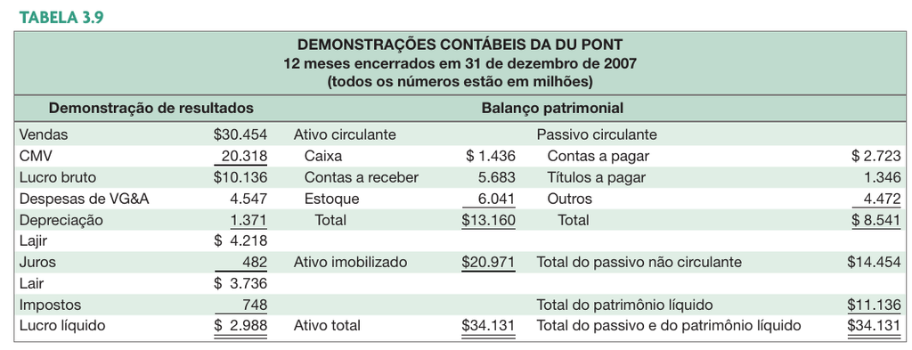

Extraído de Ross et al. (2022), página 73

## Gráfico Estendido da DuPont

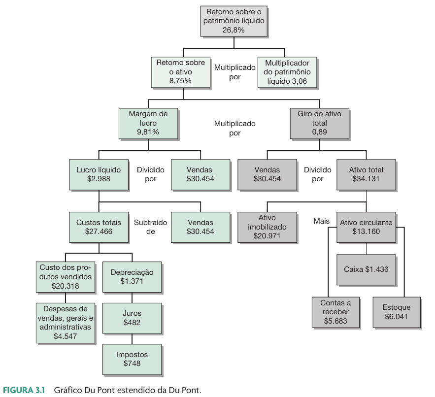

Extraído de Ross et al. (2022), página 74

# Analisando ROEs de Empresas Brasileiras

## Dados Obtidos

> **Dado um ROE variante no tempo, o que impulsionou a rentabilidade das empresas no Brasil?**

## Petrobras (PETR4 & PETR3)

- Preços Ajustados
- ROE
- Decomposição DuPont (ML, GAT, MPL)

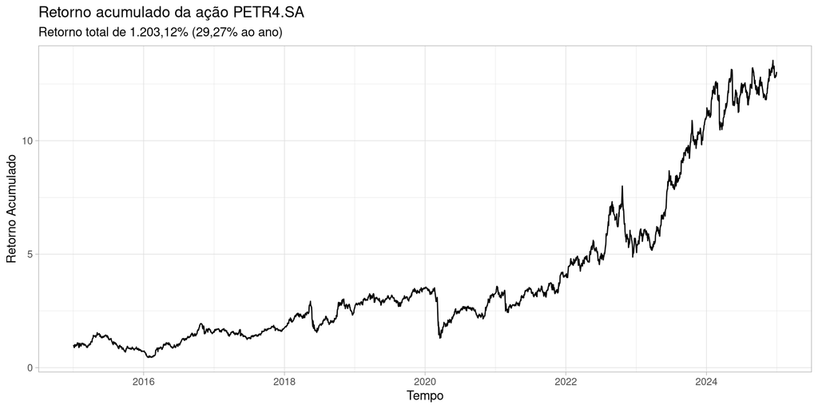

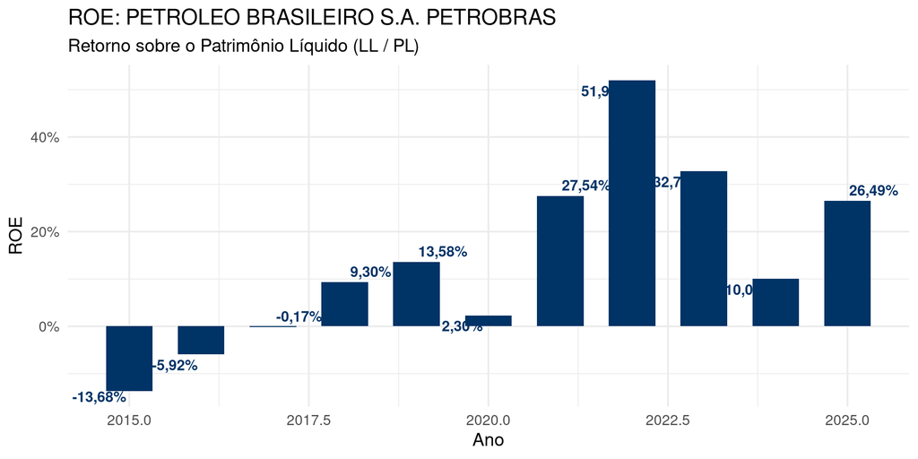

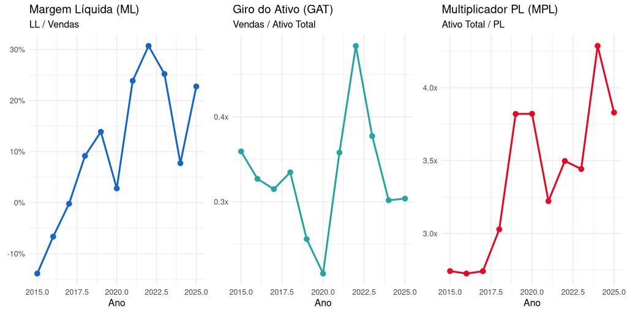

## Magazine Luiza (MGLU3)

- Preços Ajustados
- ROE
- Decomposição DuPont (ML, GAT, MPL)

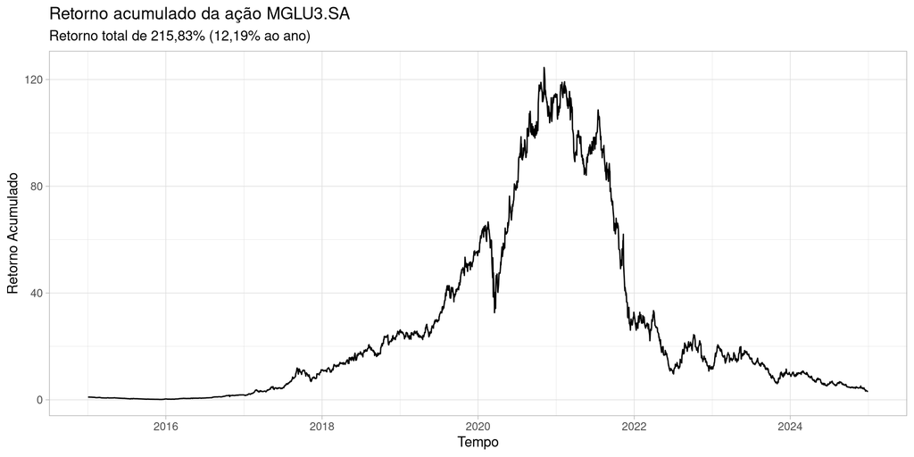

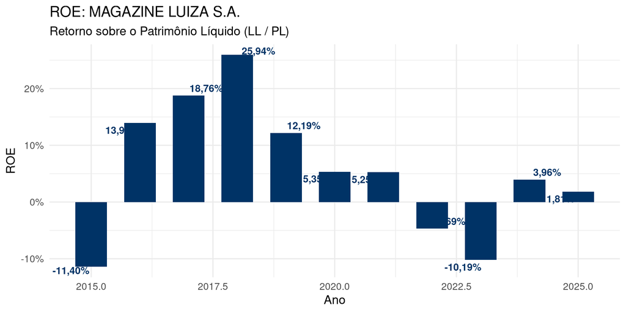

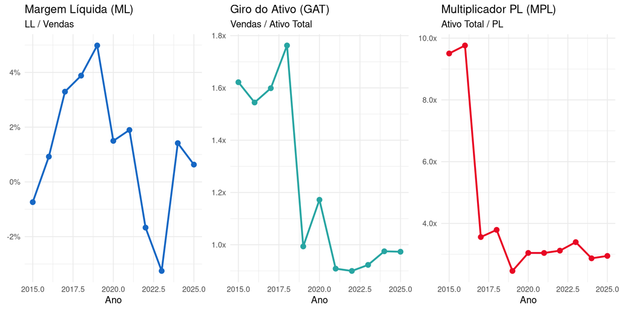

## M. Dias Branco (MDIA3)

- Preços Ajustados
- ROE
- Decomposição DuPont (ML, GAT, MPL)

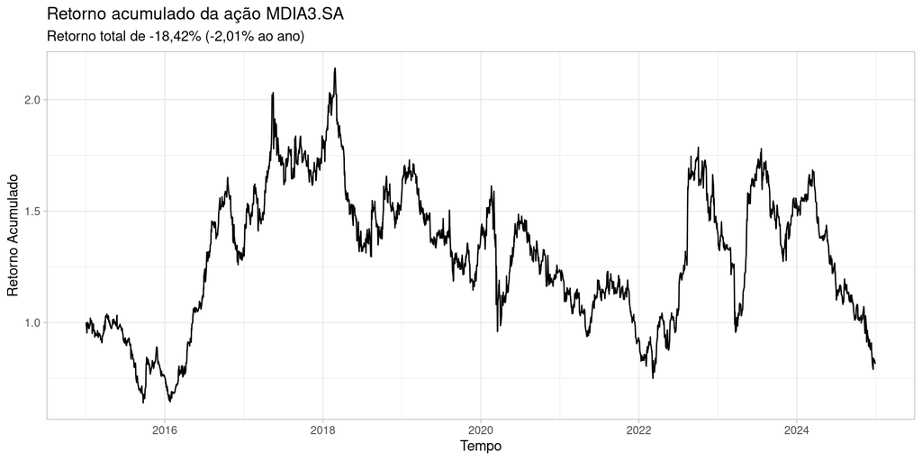

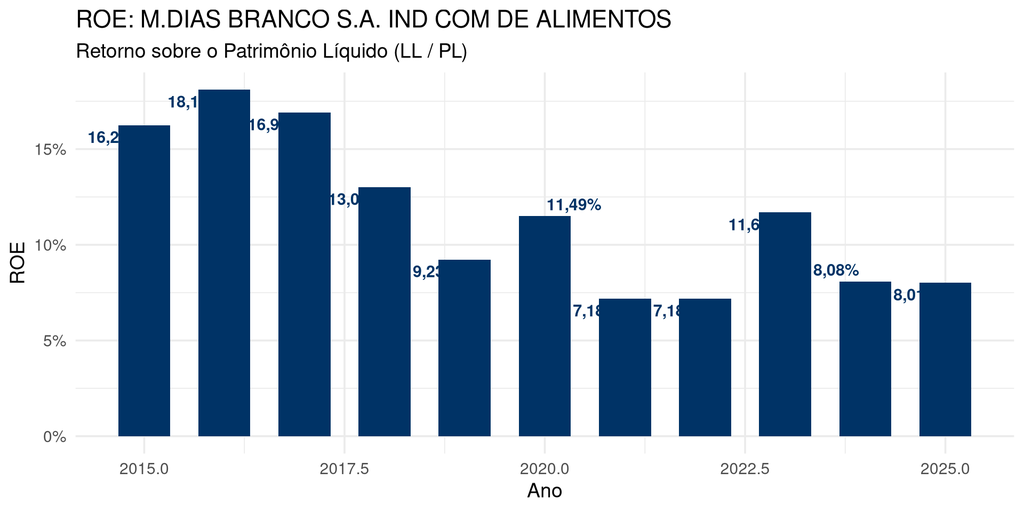

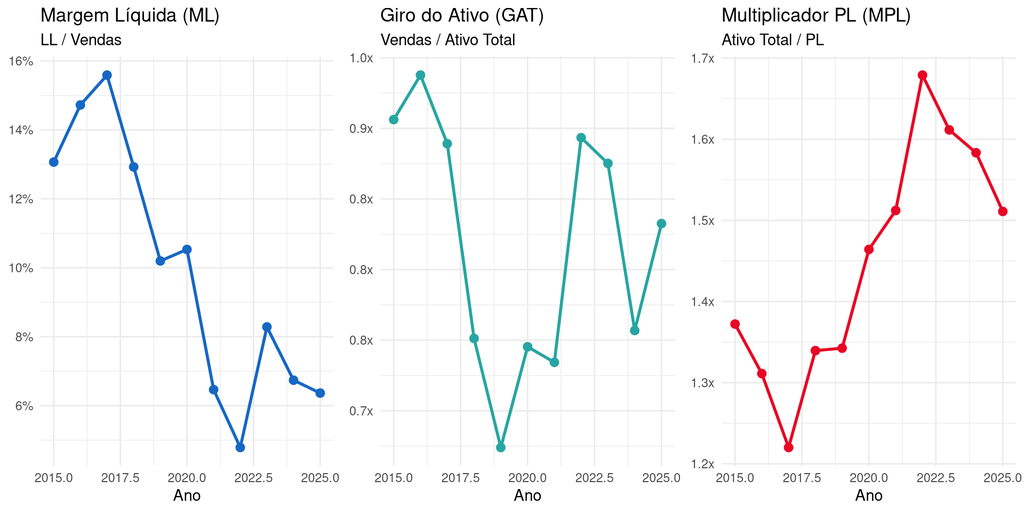

## Ambev (ABEV3)

- Preços Ajustados
- ROE
- Decomposição DuPont (ML, GAT, MPL)

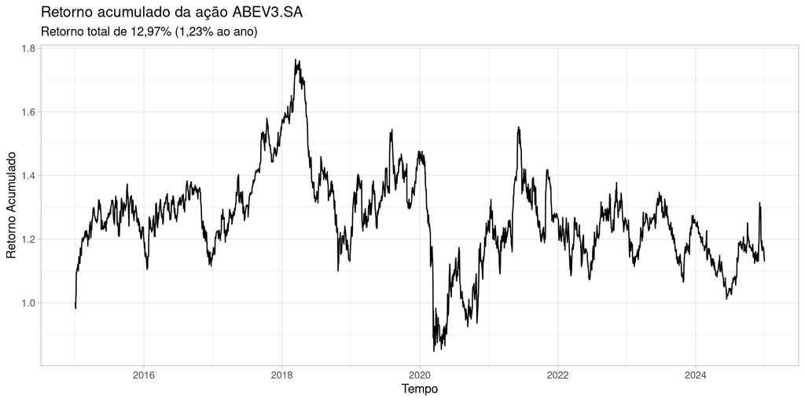

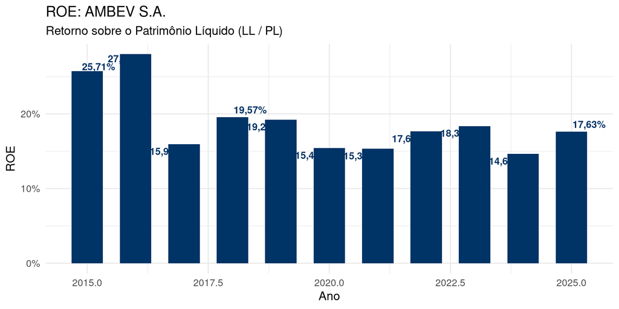

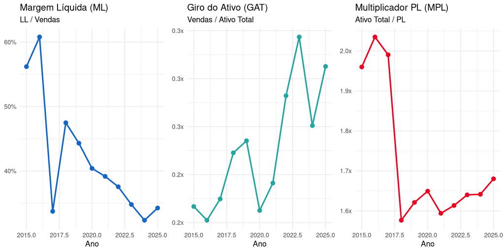

## Comparação Prática: Modelos de Negócio

| Empresa | Perfil DuPont Predominante | Característica Principal |
| --- | --- | --- |
| **Petrobras** | Alavancagem & Commodities | Alta variação em margens e impacto do custo da dívida |
| **Magalu** | Giro do Ativo ($GAT$) & Varejo | Dependente de volume/giro e sensível à taxa de juros |
| **M. Dias Branco** | Margem Líquida ($ML$) & Baixa Alavancagem | Setor alimentício estável, foco em lucratividade |
| **Ambev** | Altíssima Margem ($ML$) & Baixa Alavancagem | Poder de precificação de marca e estrutura de capital conservadora |

**Insight Didático**

Empresas no mesmo mercado podem apresentar ROEs idênticos por caminhos operacionais e financeiros completamente distintos!

# Exercício Prático e Aplicação

## Desafio em Sala: Qual Empresa Escolher?

Considere duas empresas rivais no mesmo setor com o mesmo ROE final de **18%**:

| Indicador | Empresa Alfa | Empresa Beta |
| --- | --- | --- |
| **Margem Líquida ($ML$)** | $12\%$ | $3\%$ |
| **Giro do Ativo ($GAT$)** | $0{,}5\text{x}$ | $2{,}0\text{x}$ |
| **Multiplicador do PL ($MPL$)** | $3{,}0\text{x}$ | $3{,}0\text{x}$ |
| **ROE Final** | **$18\%$** | **$18\%$** |

**Perguntas para Discussão**: 1. Qual empresa possui maior eficiência operacional no controle de custos? 2. Qual modelo de negócios tolera melhor uma retração súbita no consumo?

**Análise Didática**

- **Empresa Alfa**: Modelo focado em **diferenciação e margem** (alta proteção em quedas de vendas).
- **Empresa Beta**: Modelo focado em **giro e volume** (vulnerável a retrações do mercado).

## Referências

Perlin, Marcelo, and Guilherme Kirch. 2023. *GetDFPData2: Reading Annual and Quarterly Financial Reports from B3*. https://CRAN.R-project.org/package=GetDFPData2.

Ross, Stephen, Randolph Westerfield, Bradford Jordan, et al. 2022. *Fundamentos de Administração Financeira*. Bookman Editora.